# Project: Investigate a Dataset - [ TMDb movie data ]

- Introduction
- Data Wrangling
- Exploratory Data Analysis
- Conclusions

## Introduction

### Dataset Description

**The dataset contains information about 10,000 movies collected from The Movie Database (TMDb), including user ratings and revenue. It contains 21 columns, which are:**

1. id
2. imdb_id
3. popularity
4. budget
5. revenue
6. original_title
7. cast
8. homepage
9. director
10. tagline
11. keywords
12. overview
13. runtime
14. genres
15. production_companies
16. release_date
17. vote_count
18. vote_average
19. release_year
20. budget_adj
21. revenue_adj

*Certain columns, like ‘cast’ and ‘genres’, contain multiple values separated by pipe (|) characters. The final two columns ending with “_adj” show the budget and revenue of the associated movie in terms of 2010 dollars, accounting for inflation over time.*

### Question(s) for Analysis

*1. How has the popularity of movies changed over the years?*

*2. What kinds of properties are associated with movies that have high revenues?*

```python
import pandas as pd
import numpy as np
import matplotlib.pyplot as plt
```

## Data Wrangling

```python
data = pd.read_csv('tmdb-movies.csv')
```

```python
data.shape
```

```
(10866, 21)
```

This tmdb movies dataset have 21 columns and 10866 rows!

```python
data.head(10)
```

|  | id | imdb_id | popularity | budget | revenue | original_title | cast | homepage | director | tagline | ... | overview | runtime | genres | production_companies | release_date | vote_count | vote_average | release_year | budget_adj | revenue_adj |
| --- | --- | --- | --- | --- | --- | --- | --- | --- | --- | --- | --- | --- | --- | --- | --- | --- | --- | --- | --- | --- | --- |
| 0 | 135397 | tt0369610 | 32.985763 | 150000000 | 1513528810 | Jurassic World | Chris Pratt\|Bryce Dallas Howard\|Irrfan Khan\|Vi... | http://www.jurassicworld.com/ | Colin Trevorrow | The park is open. | ... | Twenty-two years after the events of Jurassic ... | 124 | Action\|Adventure\|Science Fiction\|Thriller | Universal Studios\|Amblin Entertainment\|Legenda... | 6/9/15 | 5562 | 6.5 | 2015 | 1.379999e+08 | 1.392446e+09 |
| 1 | 76341 | tt1392190 | 28.419936 | 150000000 | 378436354 | Mad Max: Fury Road | Tom Hardy\|Charlize Theron\|Hugh Keays-Byrne\|Nic... | http://www.madmaxmovie.com/ | George Miller | What a Lovely Day. | ... | An apocalyptic story set in the furthest reach... | 120 | Action\|Adventure\|Science Fiction\|Thriller | Village Roadshow Pictures\|Kennedy Miller Produ... | 5/13/15 | 6185 | 7.1 | 2015 | 1.379999e+08 | 3.481613e+08 |
| 2 | 262500 | tt2908446 | 13.112507 | 110000000 | 295238201 | Insurgent | Shailene Woodley\|Theo James\|Kate Winslet\|Ansel... | http://www.thedivergentseries.movie/#insurgent | Robert Schwentke | One Choice Can Destroy You | ... | Beatrice Prior must confront her inner demons ... | 119 | Adventure\|Science Fiction\|Thriller | Summit Entertainment\|Mandeville Films\|Red Wago... | 3/18/15 | 2480 | 6.3 | 2015 | 1.012000e+08 | 2.716190e+08 |
| 3 | 140607 | tt2488496 | 11.173104 | 200000000 | 2068178225 | Star Wars: The Force Awakens | Harrison Ford\|Mark Hamill\|Carrie Fisher\|Adam D... | http://www.starwars.com/films/star-wars-episod... | J.J. Abrams | Every generation has a story. | ... | Thirty years after defeating the Galactic Empi... | 136 | Action\|Adventure\|Science Fiction\|Fantasy | Lucasfilm\|Truenorth Productions\|Bad Robot | 12/15/15 | 5292 | 7.5 | 2015 | 1.839999e+08 | 1.902723e+09 |
| 4 | 168259 | tt2820852 | 9.335014 | 190000000 | 1506249360 | Furious 7 | Vin Diesel\|Paul Walker\|Jason Statham\|Michelle ... | http://www.furious7.com/ | James Wan | Vengeance Hits Home | ... | Deckard Shaw seeks revenge against Dominic Tor... | 137 | Action\|Crime\|Thriller | Universal Pictures\|Original Film\|Media Rights ... | 4/1/15 | 2947 | 7.3 | 2015 | 1.747999e+08 | 1.385749e+09 |
| 5 | 281957 | tt1663202 | 9.110700 | 135000000 | 532950503 | The Revenant | Leonardo DiCaprio\|Tom Hardy\|Will Poulter\|Domhn... | http://www.foxmovies.com/movies/the-revenant | Alejandro González Iñárritu | (n. One who has returned, as if from the dead.) | ... | In the 1820s, a frontiersman, Hugh Glass, sets... | 156 | Western\|Drama\|Adventure\|Thriller | Regency Enterprises\|Appian Way\|CatchPlay\|Anony... | 12/25/15 | 3929 | 7.2 | 2015 | 1.241999e+08 | 4.903142e+08 |
| 6 | 87101 | tt1340138 | 8.654359 | 155000000 | 440603537 | Terminator Genisys | Arnold Schwarzenegger\|Jason Clarke\|Emilia Clar... | http://www.terminatormovie.com/ | Alan Taylor | Reset the future | ... | The year is 2029. John Connor, leader of the r... | 125 | Science Fiction\|Action\|Thriller\|Adventure | Paramount Pictures\|Skydance Productions | 6/23/15 | 2598 | 5.8 | 2015 | 1.425999e+08 | 4.053551e+08 |
| 7 | 286217 | tt3659388 | 7.667400 | 108000000 | 595380321 | The Martian | Matt Damon\|Jessica Chastain\|Kristen Wiig\|Jeff ... | http://www.foxmovies.com/movies/the-martian | Ridley Scott | Bring Him Home | ... | During a manned mission to Mars, Astronaut Mar... | 141 | Drama\|Adventure\|Science Fiction | Twentieth Century Fox Film Corporation\|Scott F... | 9/30/15 | 4572 | 7.6 | 2015 | 9.935996e+07 | 5.477497e+08 |
| 8 | 211672 | tt2293640 | 7.404165 | 74000000 | 1156730962 | Minions | Sandra Bullock\|Jon Hamm\|Michael Keaton\|Allison... | http://www.minionsmovie.com/ | Kyle Balda\|Pierre Coffin | Before Gru, they had a history of bad bosses | ... | Minions Stuart, Kevin and Bob are recruited by... | 91 | Family\|Animation\|Adventure\|Comedy | Universal Pictures\|Illumination Entertainment | 6/17/15 | 2893 | 6.5 | 2015 | 6.807997e+07 | 1.064192e+09 |
| 9 | 150540 | tt2096673 | 6.326804 | 175000000 | 853708609 | Inside Out | Amy Poehler\|Phyllis Smith\|Richard Kind\|Bill Ha... | http://movies.disney.com/inside-out | Pete Docter | Meet the little voices inside your head. | ... | Growing up can be a bumpy road, and it's no ex... | 94 | Comedy\|Animation\|Family | Walt Disney Pictures\|Pixar Animation Studios\|W... | 6/9/15 | 3935 | 8.0 | 2015 | 1.609999e+08 | 7.854116e+08 |

10 rows × 21 columns

```python
data.dtypes
```

```
id                        int64
imdb_id                  object
popularity              float64
budget                    int64
revenue                   int64
original_title           object
cast                     object
homepage                 object
director                 object
tagline                  object
keywords                 object
overview                 object
runtime                   int64
genres                   object
production_companies     object
release_date             object
vote_count                int64
vote_average            float64
release_year              int64
budget_adj              float64
revenue_adj             float64
dtype: object
```

```python
data.info()
```

```
<class 'pandas.core.frame.DataFrame'>
RangeIndex: 10866 entries, 0 to 10865
Data columns (total 21 columns):
 #   Column                Non-Null Count  Dtype
---  ------                --------------  -----
 0   id                    10866 non-null  int64
 1   imdb_id               10856 non-null  object
 2   popularity            10866 non-null  float64
 3   budget                10866 non-null  int64
 4   revenue               10866 non-null  int64
 5   original_title        10866 non-null  object
 6   cast                  10790 non-null  object
 7   homepage              2936 non-null   object
 8   director              10822 non-null  object
 9   tagline               8042 non-null   object
 10  keywords              9373 non-null   object
 11  overview              10862 non-null  object
 12  runtime               10866 non-null  int64
 13  genres                10843 non-null  object
 14  production_companies  9836 non-null   object
 15  release_date          10866 non-null  object
 16  vote_count            10866 non-null  int64
 17  vote_average          10866 non-null  float64
 18  release_year          10866 non-null  int64
 19  budget_adj            10866 non-null  float64
 20  revenue_adj           10866 non-null  float64
dtypes: float64(4), int64(6), object(11)
memory usage: 1.7+ MB
```

There are missing values in (imdb_id, cast, homepage, director, tagline, keywords, overview, genres, production_companies)

```python
data.nunique()
```

```
id                      10865
imdb_id                 10855
popularity              10814
budget                    557
revenue                  4702
original_title          10571
cast                    10719
homepage                 2896
director                 5067
tagline                  7997
keywords                 8804
overview                10847
runtime                   247
genres                   2039
production_companies     7445
release_date             5909
vote_count               1289
vote_average               72
release_year               56
budget_adj               2614
revenue_adj              4840
dtype: int64
```

### Data Cleaning

There are many missing data! but luckily all of them are Extraneous columns that are not relevant or needed for the analysis I am working on. Therefore, I have decided to drop them since there is no need for them. Yet, I will keep some needed columns by only deleting the null rows.

```python
#1. rechecking for missing values
data.isnull().sum()
```

```
id                         0
imdb_id                   10
popularity                 0
budget                     0
revenue                    0
original_title             0
cast                      76
homepage                7930
director                  44
tagline                 2824
keywords                1493
overview                   4
runtime                    0
genres                    23
production_companies    1030
release_date               0
vote_count                 0
vote_average               0
release_year               0
budget_adj                 0
revenue_adj                0
dtype: int64
```

```python
#Dropping Extraneous columns
data.drop(['cast', 'homepage', 'director', 'tagline', 'keywords', 'overview', 'production_companies'], axis=1, inplace=True)
```

```python
#check after dropping columns
data.head(1)
```

|  | id | imdb_id | popularity | budget | revenue | original_title | runtime | genres | release_date | vote_count | vote_average | release_year | budget_adj | revenue_adj |
| --- | --- | --- | --- | --- | --- | --- | --- | --- | --- | --- | --- | --- | --- | --- |
| 0 | 135397 | tt0369610 | 32.985763 | 150000000 | 1513528810 | Jurassic World | 124 | Action\|Adventure\|Science Fiction\|Thriller | 6/9/15 | 5562 | 6.5 | 2015 | 1.379999e+08 | 1.392446e+09 |

```python
data.isnull().sum()
```

```
id                 0
imdb_id           10
popularity         0
budget             0
revenue            0
original_title     0
runtime            0
genres            23
release_date       0
vote_count         0
vote_average       0
release_year       0
budget_adj         0
revenue_adj        0
dtype: int64
```

```python
#Drop rows with any null values
data = data.dropna()
```

```python
data.isnull().sum().any()
```

```
False
```

```python
data.isnull().sum()
```

```
id                0
imdb_id           0
popularity        0
budget            0
revenue           0
original_title    0
runtime           0
genres            0
release_date      0
vote_count        0
vote_average      0
release_year      0
budget_adj        0
revenue_adj       0
dtype: int64
```

```python
#2.Checking for duplicates
data.duplicated()
```

```
0        False
1        False
2        False
3        False
4        False
         ...
10861    False
10862    False
10863    False
10864    False
10865    False
Length: 10835, dtype: bool
```

```python
sum(data.duplicated())
```

```
1
```

```python
#Drop the duplicated
data.drop_duplicates(inplace=True)
```

```python
sum(data.duplicated())
```

```
0
```

Here comes the end of the data cleaning! I have dealt with missing values by dropping the unnecessary columns, and dropping the rows of useful and needed columns. For the duplicates, I have also dropped them. Now, moving to Exploration!

## Exploratory Data Analysis

### How has the popularity of movies changed over the years?

### 1) Single-variable (1d) exploration

```python
# Group by release year and calculate the mean popularity for each year
popularity_over_years = data.groupby('release_year')['popularity'].mean(numeric_only=True)
```

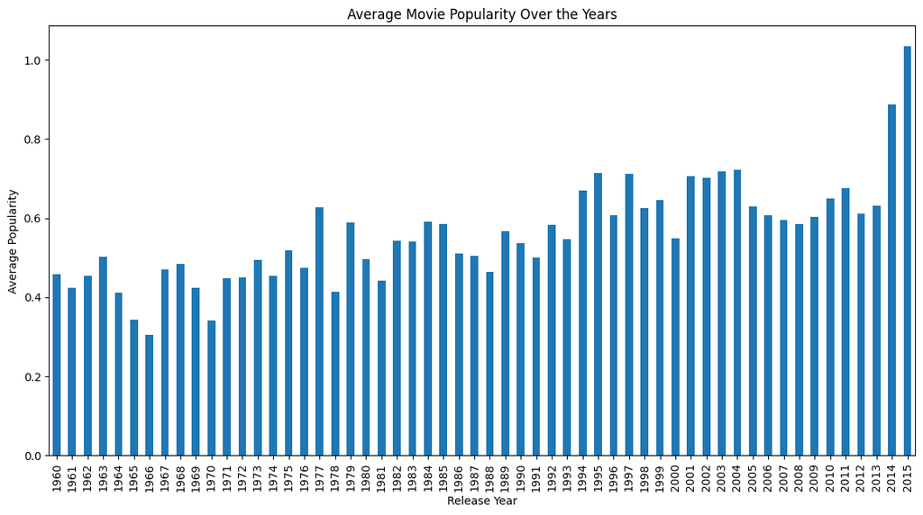

```python
# Plot the trend of popularity over the years
popularity_over_years.plot(
    kind="bar",
    x="release_year",
    title="Average Movie Popularity Over the Years",
    legend=False,
    xlabel="Release Year",
    ylabel="Average Popularity",
    figsize=(14, 7)
);
```

Wow! in the year 2015, the popularity of movies has remarkably increased unlike previous years

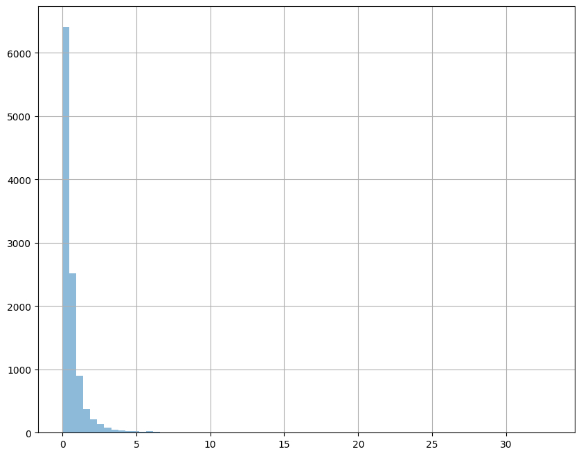

```python
# Plot the distribution of movie popularity
data['popularity'].hist(alpha=0.5, figsize=(10, 8), bins=70);
```

The histogram is right-skewed, indicating that most of the movies have low popularity scores, while only few movies are highly popular

### 2) Multiple-variable (2d) exploration

#### Popularity & genres:

```python
# Explode the genres column to analyze each genre separately
d_genres = data.dropna(subset=['genres'])
d_genres =  d_genres.assign(genres=d_genres['genres'].str.split('|').explode('genres'))
d_genres
```

|  | id | imdb_id | popularity | budget | revenue | original_title | runtime | genres | release_date | vote_count | vote_average | release_year | budget_adj | revenue_adj |
| --- | --- | --- | --- | --- | --- | --- | --- | --- | --- | --- | --- | --- | --- | --- |
| 0 | 135397 | tt0369610 | 32.985763 | 150000000 | 1513528810 | Jurassic World | 124 | Action | 6/9/15 | 5562 | 6.5 | 2015 | 1.379999e+08 | 1.392446e+09 |
| 1 | 76341 | tt1392190 | 28.419936 | 150000000 | 378436354 | Mad Max: Fury Road | 120 | Adventure | 5/13/15 | 6185 | 7.1 | 2015 | 1.379999e+08 | 3.481613e+08 |
| 2 | 262500 | tt2908446 | 13.112507 | 110000000 | 295238201 | Insurgent | 119 | Science Fiction | 3/18/15 | 2480 | 6.3 | 2015 | 1.012000e+08 | 2.716190e+08 |
| 3 | 140607 | tt2488496 | 11.173104 | 200000000 | 2068178225 | Star Wars: The Force Awakens | 136 | Thriller | 12/15/15 | 5292 | 7.5 | 2015 | 1.839999e+08 | 1.902723e+09 |
| 4 | 168259 | tt2820852 | 9.335014 | 190000000 | 1506249360 | Furious 7 | 137 | Action | 4/1/15 | 2947 | 7.3 | 2015 | 1.747999e+08 | 1.385749e+09 |
| ... | ... | ... | ... | ... | ... | ... | ... | ... | ... | ... | ... | ... | ... | ... |
| 10861 | 21 | tt0060371 | 0.080598 | 0 | 0 | The Endless Summer | 95 | Romance | 6/15/66 | 11 | 7.4 | 1966 | 0.000000e+00 | 0.000000e+00 |
| 10862 | 20379 | tt0060472 | 0.065543 | 0 | 0 | Grand Prix | 176 | Drama | 12/21/66 | 20 | 5.7 | 1966 | 0.000000e+00 | 0.000000e+00 |
| 10863 | 39768 | tt0060161 | 0.065141 | 0 | 0 | Beregis Avtomobilya | 94 | Thriller | 1/1/66 | 11 | 6.5 | 1966 | 0.000000e+00 | 0.000000e+00 |
| 10864 | 21449 | tt0061177 | 0.064317 | 0 | 0 | What's Up, Tiger Lily? | 80 | Crime | 11/2/66 | 22 | 5.4 | 1966 | 0.000000e+00 | 0.000000e+00 |
| 10865 | 22293 | tt0060666 | 0.035919 | 19000 | 0 | Manos: The Hands of Fate | 74 | Drama | 11/15/66 | 15 | 1.5 | 1966 | 1.276423e+05 | 0.000000e+00 |

10834 rows × 14 columns

```python
# Group by genre and release year, then calculate the mean popularity
genre_popularity_over_years = d_genres.groupby(['release_year', 'genres'])['popularity'].mean(numeric_only=True).reset_index()
```

```python
genre_popularity_over_years
```

|  | release_year | genres | popularity |
| --- | --- | --- | --- |
| 0 | 1960 | Action | 0.333643 |
| 1 | 1960 | Adventure | 0.208543 |
| 2 | 1960 | Animation | 0.169580 |
| 3 | 1960 | Comedy | 0.502014 |
| 4 | 1960 | Crime | 0.127219 |
| ... | ... | ... | ... |
| 902 | 2015 | Science Fiction | 2.260981 |
| 903 | 2015 | TV Movie | 0.036987 |
| 904 | 2015 | Thriller | 1.014418 |
| 905 | 2015 | War | 0.607246 |
| 906 | 2015 | Western | 1.532170 |

907 rows × 3 columns

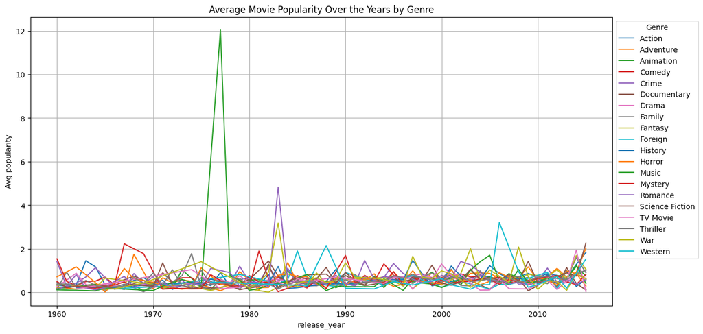

```python
genre_popularity_over_years.set_index('release_year').groupby('genres')['popularity'].plot(
    kind="line",
    figsize=(14,7),
    x="release_year",
    title="Average Movie Popularity Over the Years by Genre",
    legend=True,
    xlabel="release_year",
    ylabel="Avg popularity",
    grid=True
);
plt.legend(title='Genre', bbox_to_anchor=(1, 1), loc='upper left')
```

We can see from the line plot above that represents the average popularity of movies from different genres across various release years, in between 1970 and 1980 the genre "Music" was most popular. Also, in between 1980-1990 both "Crime" & "Fantasy" had an increase in popularity. While in 1990-2000, we can notice that the popularity of movies got kind of lower somehow. Overall, it appears that the average popularity of movies has fluctuated over time.

#### Popularity, Budget, and Revenue Over the Years:

```python
# Group by release year and calculate the mean budget, revenue, and popularity for each year
budget_revenue_popularity_over_years = data.groupby('release_year')[['budget', 'revenue', 'popularity']].mean(numeric_only=True).reset_index()
```

```python
# Include at least one function to replace repetitive code
def plot_dual_yaxes(data, x_col, y1_col, y2_col, y1_label, y2_label, y1_color, y2_color, title):
    fig, ax1 = plt.subplots(figsize=(14, 7))  # Create figure and primary y-axis

    # Plotting on primary y-axis
    ax1.plot(data[x_col], data[y1_col], color=y1_color, label=y1_label)
    ax1.set_xlabel('Release Year')
    ax1.set_ylabel(y1_label)
    ax1.legend(loc='upper left')

    # Creating secondary y-axis
    ax2 = ax1.twinx()
    ax2.plot(data[x_col], data[y2_col], color=y2_color, label=y2_label)
    ax2.set_ylabel(y2_label)
    ax2.legend(loc='upper right')

    # Setting title and displaying plot
    fig.suptitle(title)
    plt.grid(True)
    plt.show()
```

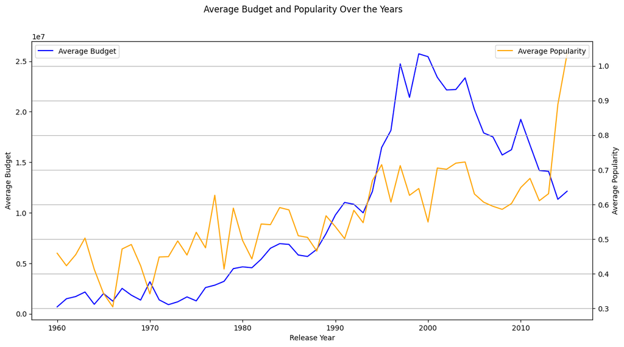

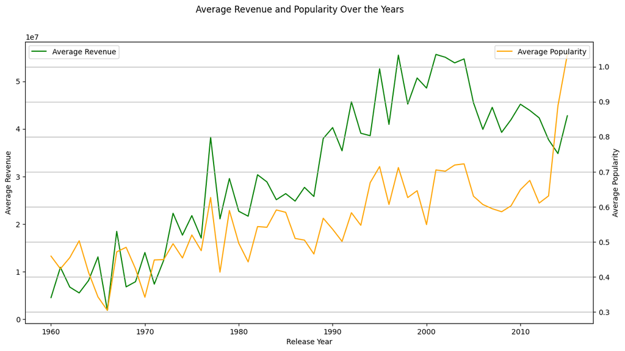

```python
# plotting budget and popularity over the years
plot_dual_yaxes(
    budget_revenue_popularity_over_years,
    'release_year',
    'budget',
    'popularity',
    'Average Budget',
    'Average Popularity',
    'blue',
    'orange',
    'Average Budget and Popularity Over the Years'
)

# plotting revenue and popularity over the years
plot_dual_yaxes(
    budget_revenue_popularity_over_years,
    'release_year',
    'revenue',
    'popularity',
    'Average Revenue',
    'Average Popularity',
    'green',
    'orange',
    'Average Revenue and Popularity Over the Years'
)
```

The first plot shows trends in **average budget & popularity of movies over the years**. There is a noticeable increase in budgets starting in the mid 1980s, peaking around the early 2000s, followed by some declines but overall remaining high. Popularity trends show more fluctuations, with stability until the mid 1980s, a peak in the 1990s, a decline, and another peak around 2015. Initially, there is a weak correlation between budget and popularity, but from the mid 1980s onwards, increased budgets often align with higher popularity. Despite this, the trend is not always consistent, especially post 2010, suggesting other factors besides budget influence a movie's popularity, such as Revenue.